# 13 R: Data structures

R has several **data structures** to store and manipulate data efficiently. These structures can be classified into **homogeneous** (same type) and **heterogeneous** (different types) categories.

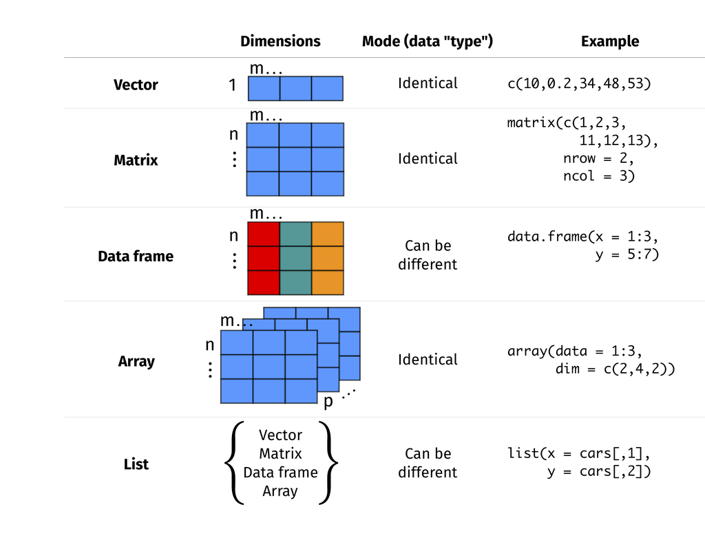

## 13.1 Atomic vectors ((1D, Homogeneous))

**Atomic vectors** are the most fundamental data type in R. They are **one-dimensional collections of elements**, where all elements must share the **same data type**.

Since atomic vectors were covered in the previous chapter, this chapter will focus on the remaining three data structures: **matrices, lists, and data frames**.

## 13.2 Matrix ((2D, Homogeneous))

Matrices are two-dimensional arrays.

### 13.2.1 Creating a matrix

The built-in function `matrix()` is used to define a matrix. An atomic vector can be organized as a matrix by specifying the number of rows and columns.

For example, let us define a 3x3 matrix (3 rows and 3 columns) consisting of consecutive integers from 1 to 9.

```r
mat <- matrix(1:9, 3, 3)
mat
```

```
     [,1] [,2] [,3]
[1,]    1    4    7
[2,]    2    5    8
[3,]    3    6    9
```

Note that the integers fill up column-wise in the matrix. If we wish to fill-up the matrix by row, we can use the `byrow` argument.

```r
mat <- matrix(1:9, 3, 3, byrow = TRUE)
mat
```

```
     [,1] [,2] [,3]
[1,]    1    2    3
[2,]    4    5    6
[3,]    7    8    9
```

### 13.2.2 Getting matrix dimensions, the number of rows, the number of columns

Get matrix dimensions will give vector of c(rows, cols): - `dim()`

```r
dim(mat)
```

```
[1] 3 3
```

Get number of elements: length()

```r
length(mat)
```

```
[1] 9
```

The functions `nrow()` and `ncol()` can be used to get the number of rows and columns of the matrix respectively.

```r
nrow(mat)
```

```
[1] 3
```

```r
ncol(mat)
```

```
[1] 3
```

### 13.2.3 Matrix indexing and Slicing

Matrices can be sliced using the indices of row and column separated by a `,` in box brackets. Suppose we wish to get the element in the $2^{nd}$ row and $3^{rd}$ column of the matrix:

```r
mat[2, 3]
```

```
[1] 6
```

For selecting all rows or columns of a matrix, the index for the row/column can be left blank. Suppose we wish to get all the elements of the $1^{st}$ of the matrix:

```r
mat[1, ]
```

```
[1] 1 2 3
```

Row and columns of the matrix can be sliced using the `:` operator. Suppose we want to select a sub-matrix that has elements in the first two rows and columns 2 and 3 of the matrix `mat`:

```r
mat[1:2, 2:3]
```

```
     [,1] [,2]
[1,]    2    3
[2,]    5    6
```

### 13.2.4 Working with `rownames()` and `colnames()`

In R, row names (`rownames()`) and column names (`colnames()`) allow you to label and reference rows and columns in matrices and data frames efficiently.

```r
# Create a matrix
mat <- matrix(1:9, nrow = 3, byrow = TRUE)

# Assign row names
rownames(mat) <- c("Row1", "Row2", "Row3")

# Assign column names
colnames(mat) <- c("Col1", "Col2", "Col3")

# Print matrix
print(mat)
```

```
     Col1 Col2 Col3
Row1    1    2    3
Row2    4    5    6
Row3    7    8    9
```

Getting and Modifying Names

```r
rownames(mat)  # Get row names
```

```
[1] "Row1" "Row2" "Row3"
```

```r
colnames(mat)  # Get column names
```

```
[1] "Col1" "Col2" "Col3"
```

```r
rownames(mat) <- c("A", "B", "C")  # Modify row names
colnames(mat) <- c("X", "Y", "Z")  # Modify column names

print(mat)
```

```
  X Y Z
A 1 2 3
B 4 5 6
C 7 8 9
```

### 13.2.5 Adding and Removing

- use `cbind()` to add a column of correct length
- use `rbind()` to add a row of correct length
- if length is incorrect there will be a warning (no error it will still run), however it will “recycle” values.
- When adding a row or a col, you CANNOT insert it between the existing rows/cols. However, you can re-arrange AFTER it is added using indexing.
- use negative indexes to remove rows/columns

```r
new_col <- c(7, 8, 9)

# add the column
mat_new <- cbind(mat, new_col)
print(mat_new)
```

```
  X Y Z new_col
A 1 2 3       7
B 4 5 6       8
C 7 8 9       9
```

```r
mat_new <- cbind(mat, new_col = 5)
print(mat_new)
```

```
  X Y Z new_col
A 1 2 3       5
B 4 5 6       5
C 7 8 9       5
```

```r
new_row <- c(7, 8, 9)

# add the row
mat_new <- rbind(mat, new_row)
print(mat_new)
```

```
        X Y Z
A       1 2 3
B       4 5 6
C       7 8 9
new_row 7 8 9
```

```r
mat_new <- rbind(mat, new_row = 5)
print(mat_new)
```

```
        X Y Z
A       1 2 3
B       4 5 6
C       7 8 9
new_row 5 5 5
```

```r
# remove the added row
mat_new <- mat_new[-4, ]
print(mat_new)
```

```
  X Y Z
A 1 2 3
B 4 5 6
C 7 8 9
```

```r
# remove the added column
mat_new <- mat_new[, -4]
print(mat_new)
```

```
  X Y Z
A 1 2 3
B 4 5 6
C 7 8 9
```

### 13.2.6 Iterating

To iterate through each element you generally need a nested loop combined with `nrow()` and `ncol()`

```r
for (i in 1: nrow(mat_new)){
  for (j in 1: ncol(mat_new)) {
    print(paste("Element at (", i, ",", j, "):", mat[i, j]))
  }
}
```

```
[1] "Element at ( 1 , 1 ): 1"
[1] "Element at ( 1 , 2 ): 2"
[1] "Element at ( 1 , 3 ): 3"
[1] "Element at ( 2 , 1 ): 4"
[1] "Element at ( 2 , 2 ): 5"
[1] "Element at ( 2 , 3 ): 6"
[1] "Element at ( 3 , 1 ): 7"
[1] "Element at ( 3 , 2 ): 8"
[1] "Element at ( 3 , 3 ): 9"
```

### 13.2.7 Element-wise arithmetic operations

Element-wise arithmetic operations have the same logic with atomic vectors, they can be performed between 2 matrices of the same shape.

```r
mat1 <- matrix(1:6, 2, 3)
mat2 <- matrix(c(9, 2, 6, 5, 1, 0), 2, 3)
mat1 + mat2
```

```
     [,1] [,2] [,3]
[1,]   10    9    6
[2,]    4    9    6
```

```r
mat1 - mat2
```

```
     [,1] [,2] [,3]
[1,]   -8   -3    4
[2,]    0   -1    6
```

Suppose we need to sum up all the rows of the matrix. We can do it using a `for` loop as follows:

```r
row_sum <- c(0,0)
for (i in 1:nrow(mat)) {
  for (j in 1:ncol(mat)) {
    row_sum[i] <- row_sum[i] + mat[i, j]
  }
}
row_sum
```

```
[1]  6 15 NA
```

Observe that in the above `for` loop, elements of each row are added one at a time. We can add all the elements of a row simultaneously using the `sum()` function. This will reduce a `for` loop from the above code:

```r
row_sum <- c(0,0)
for (i in 1:nrow(mat)){
  row_sum[i] <- sum(mat[i,])
}
row_sum
```

```
[1]  6 15 24
```

In the above code, we sum up all the elements of the row simultaneously. However, we still need to sum up the elements of each row one at a time.

#### 13.2.7.1 Matrix multiplication vs. element-wise multiplication

- Matrix multiplication: using `%*%`

```r
# Create another 3x3 matrix
mat2 <- matrix(9:1, nrow = 3)

# Perform matrix multiplication
result <- mat %*% mat2
print(result)
```

```
  [,1] [,2] [,3]
A   46   28   10
B  118   73   28
C  190  118   46
```

- Element-wise multiplication: using `*`

```r
# Element-wise multiplication
mat * mat
```

```
   X  Y  Z
A  1  4  9
B 16 25 36
C 49 64 81
```

### 13.2.8 The `apply()` function

The `apply()` function can be used to apply a function on each row or column of a matrix. Thus, this function helps avoid the user to write a `for()` loop in R to iterate over all the rows and columns of the matrix. Note that each row / column of a matrix is an atomic vector. Thus, vectorized computations can be performed within the function, resulting in efficient computations.

Note that the apply functions use a `for()` loop under-the-hood, and thus the function will be applied sequentially on each row / column of the matrix. However, as the implementation of the `for()` loop is in C, it is likely to be faster than a `for()` loop in R.

Let us use the `apply()` function to sum up all the rows of the matrix `mat`.

```r
apply(mat, 1, sum)
```

```
 A  B  C
 6 15 24
```

Let us compare the time taken to sum up rows of a matrix using a `for` loop with the time taken using the `apply()` function.

```r
options(digits.secs = 6)
start.time <- Sys.time()
row_sum<-c(0, 0)
for (i in 1:nrow(mat)){
  row_sum[i] <- sum(mat[i,])
}
row_sum
```

```
[1]  6 15 24
```

```r
end.time <- Sys.time()
time.taken <- end.time - start.time
time.taken
```

```
Time difference of 0.004702806 secs
```

```r
start.time <- Sys.time()
apply(mat, 1, sum)
```

```
 A  B  C
 6 15 24
```

```r
end.time <- Sys.time()
time.taken <- end.time - start.time
time.taken
```

```
Time difference of 0.001413822 secs
```

Observe that the `apply()` function takes much lesser time to sum up all the rows of the matrix as compared to the `for` loop.

### 13.2.9 Misc useful functions:

Check if a value/string is in the matrix:

- `"val" %in% my_mat`

```r
# Create a matrix
fruit_mat <- matrix(c("apple", "banana", "cherry", "date"), nrow=2, byrow=TRUE)

# Check if "banana" is in the matrix
"banana" %in% fruit_mat
```

```
[1] TRUE
```

```r
# Check if "grape" is in the matrix
"grape" %in% fruit_mat
```

```
[1] FALSE
```

If you want to return TRUE or FALSE directly:

```r
any(fruit_mat == "banana")
```

```
[1] TRUE
```

```r
any(fruit_mat == "grape")
```

```
[1] FALSE
```

```r
which(mat == "banana", arr.ind = TRUE)
```

```
     row col
```

Check if a value is missing (ie: NA):

- `is.na(val)`

## 13.4 Lists (1D, Heterogeneous)

Atomic vectors and matrices are quite useful in R. However, a constraint with them is that they can only contain objects of the same datatype. For example, an atomic vector can contain all numeric objects, all character objects, or all logical objects, but not a mixture of multiple types of objects. Thus, there arises a need for a `list` data structure that can store objects of multiple datatypes.

### 13.4.1 Creating and Indexing

A list can be defined using the `list()` function. For example, consider the list below:

```r
list_ex <- list(1, "apple", TRUE, list("another list", TRUE))
```

The list `list_ex` consists of objects of mutiple datatypes. The length of the list can be obtained using the `length()`function:

```r
length(list_ex)
```

```
[1] 4
```

A list is an ordered collection of objects. Each object of the list is associated with an index that corresponds to its order of occurrence in the list.

A single element can be sliced from the list by specifying its index within the `[[]]` operator. Let us slice the $2^{nd}$ element of the list `list_ex`:

```r
list_ex[[2]]
```

```
[1] "apple"
```

Multiple elements can be sliced from the list by specifying the indices as an atomic vector within the `[]` operator. Let us slice the $1^{st}$ and $3^{rd}$ elements from the list `list_ex`:

```r
list_ex[c(1,3)]
```

```
[[1]]
[1] 1

[[2]]
[1] TRUE
```

### 13.4.2 Naming a list

Elements of a list can be named using the `names()` function. Let us name the elements of `list_ex`:

```r
names(list_ex) <- c("Name1", "second_name", "3rd_element", "Number 4")
```

A single element can be sliced from the list using the name of the element with the `$` operator. Let us slice the element named as `second_name` from the list `list_ex`:

```r
list_ex$second_name
```

```
[1] "apple"
```

```r
list_ex$`3rd_element`
```

```
[1] TRUE
```

Names of elements of a list can also be specified while defining the list, as in the example below:

```r
list_ex_with_names <- list(movie = 'The Dark Knight', IMDB_rating = 9)
```

### 13.4.3 Using as Function Input

No arithmetic or logical operations with a list, since elements are with different data types. A list can be converted to an atomic vector using the `unlist()` function. For example, let us convert the list `list_ex` to a vector:

```r
unlist(list_ex)
```

```
         Name1    second_name    3rd_element      Number 41      Number 42
           "1"        "apple"         "TRUE" "another list"         "TRUE"
```

Since a vector can contain objects of a single datatype, note that all objects have been converted to the `character` datatype in the vector above.

Another example:

```r
# Define a list with mixed data types
my_list <- list(a = 1, b = 2, c = "text", d = 4, e = TRUE)

# Function to sum numeric elements in the list
sum_list_numeric <- function(lst) {
  # Convert list to a vector, forcing non-numeric elements to NA
  vec <- unlist(lst)

  # Keep only numeric values (ignoring non-numeric ones)
  numeric_values <- as.numeric(vec[!is.na(as.numeric(vec))])

  # Compute sum
  return(sum(numeric_values))
}

# Call the function
result <- sum_list_numeric(my_list)
print(result)
```

```
[1] 7
```

### 13.4.4 Applying a function to each element of a list: the `lapply()` function

```r
# Define a list with numeric values
num_list <- list(a = 1:5, b = 6:10, c = 11:15)

# Use lapply() to compute the sum of each list element
sum_results <- lapply(num_list, sum)

# Print the result
print(sum_results)
```

```
$a
[1] 15

$b
[1] 40

$c
[1] 65
```

- Using lapply() with an Anonymous Function

```r
# Compute the mean of each element in the list
mean_results <- lapply(num_list, function(x) mean(x))

# Print the result
print(mean_results)
```

```
$a
[1] 3

$b
[1] 8

$c
[1] 13
```

## 13.5 Data Frames (2D, Heterogeneous)

A data frame is a table-like structure where each column is a vector. Unlike matrices, columns can have different types.

### 13.5.1 Creating data Frames

```r
df <- data.frame(Name=c("Alice", "Bob", "Charlie"),
                 Age=c(25, 30, 35),
                 Score=c(90, 85, 88))

print(df)
```

```
     Name Age Score
1   Alice  25    90
2     Bob  30    85
3 Charlie  35    88
```

### 13.5.2 Common functions

| Function | Purpose |
| --- | --- |
| `nrow(df)` | Number of rows |
| `ncol(df)` | Number of columns |
| `dim(df)` | Returns (rows, columns) as a vector |
| `length(df)` | Number of columns (since a data frame is a list of columns) |
| `rownames(df)` | Returns row names |
| `colnames(df)` | Returns column names |
| `str(df)` | Displays the structure of the data frame, including column types and values |
| `head(df)` | Returns the first six rows of the data frame |

### 13.5.3 Missing values

#### 13.5.3.1 Using `is.na()`

```r
# Sample data frame with missing values
df_missing <- data.frame(Name = c("Alice", "Bob", "Charlie"),
                 Age = c(25, NA, 35),
                 Score = c(90, 85, NA))

# Check for missing values (returns TRUE/FALSE matrix)
is.na(df_missing)
```

```
      Name   Age Score
[1,] FALSE FALSE FALSE
[2,] FALSE  TRUE FALSE
[3,] FALSE FALSE  TRUE
```

`is.na(df)` returns a matrix where TRUE indicates a missing value.

#### 13.5.3.2 Count the number of total missing values

```r
sum(is.na(df))
```

```
[1] 0
```

Counts all `NA` values in the entire data frame.

#### 13.5.3.3 Count missing values by column

```r
colSums(is.na(df))
```

```
 Name   Age Score
    0     0     0
```

#### 13.5.3.4 Find Rows Containing NA Values

```r
df[!complete.cases(df), ]
```

```
[1] Name  Age   Score
<0 rows> (or 0-length row.names)
```

Common functions on missing values

| Function | Purpose |
| --- | --- |
| `is.na(df)` | Returns a matrix of `TRUE/FALSE` for missing values |
| `sum(is.na(df))` | Counts the total number of missing values |
| `colSums(is.na(df))` | Counts missing values per column |
| `df[!complete.cases(df), ]` | Shows only rows that contain missing values |
| `any(is.na(df))` | Returns `TRUE` if any missing values exist |
| `mean(is.na(df))` | Returns the proportion of missing values |

### 13.5.4 Accessing Data Frame Elements

```r
df$Name   # Accessing a column
```

```
[1] "Alice"   "Bob"     "Charlie"
```

```r
df[2, ]   # Second row
```

```
  Name Age Score
2  Bob  30    85
```

```r
df[ , "Age"]  # Age column
```

```
[1] 25 30 35
```

```r
df[1:2, c("Name", "Score")]  # Subset
```

```
   Name Score
1 Alice    90
2   Bob    85
```

### 13.5.5 Using Logical Operators for Data Frame Subsetting

#### 13.5.5.1 Using Logical Operators (`[ ]`)

You can filter rows based on conditions using comparison operators (`==`, `>`, `<`, `>=`, `<=`, `!=`):

```r
filtered_df <- df[df$Score == 90, ]
print(filtered_df)
```

```
   Name Age Score
1 Alice  25    90
```

```r
filtered_df <- df[df$Age > 25, ]
print(filtered_df)
```

```
     Name Age Score
2     Bob  30    85
3 Charlie  35    88
```

- `df$Age > 25` creates a logical vector (`FALSE`, `TRUE`, `TRUE`).
- `df[df$Age > 25, ]` selects rows where `Age` is greater than 25.
- Uses `==` to filter rows where `Score` is exactly 90.

#### 13.5.5.2 Using `subset()` function

```r
filtered_df <- subset(df, Age > 25)
print(filtered_df)
```

```
     Name Age Score
2     Bob  30    85
3 Charlie  35    88
```

#### 13.5.5.3 Filter using multiple conditions

You can combine multiple conditions with `&` (AND) and `|` (OR):

```r
filtered_df <- df[df$Age > 25 & df$Score > 85, ]
print(filtered_df)
```

```
     Name Age Score
3 Charlie  35    88
```

Using `subset()`

```r
filtered_df <- subset(df, Age > 28 & Score > 85)
print(filtered_df)
```

```
     Name Age Score
3 Charlie  35    88
```

```r
filtered_df <- df[df$Age < 30 | df$Score > 85, ]
print(filtered_df)
```

```
     Name Age Score
1   Alice  25    90
3 Charlie  35    88
```

```r
# Filter and select only the "Name" and "Score" columns
filtered_df <- subset(df, Age > 28 & Score > 85, select = c(Name, Score))
print(filtered_df)
```

```
     Name Score
3 Charlie    88
```

### 13.5.6 Iterating

```r
# Iterate over rows
for (i in 1:nrow(df)) {
  print(paste("Row", i, ":", df[i, ]))
}
```

```
[1] "Row 1 : Alice" "Row 1 : 25"    "Row 1 : 90"
[1] "Row 2 : Bob" "Row 2 : 30"  "Row 2 : 85"
[1] "Row 3 : Charlie" "Row 3 : 35"      "Row 3 : 88"
```

```r
for (col in names(df)) {
  print(paste("Column:", col))
  print(df[[col]])  # Access column by name
}
```

```
[1] "Column: Name"
[1] "Alice"   "Bob"     "Charlie"
[1] "Column: Age"
[1] 25 30 35
[1] "Column: Score"
[1] 90 85 88
```

```r
for (i in 1:nrow(df)) {
  for (j in 1:ncol(df)) {
    print(paste("Element at [", i, ",", j, "]:", df[i, j]))
  }
}
```

```
[1] "Element at [ 1 , 1 ]: Alice"
[1] "Element at [ 1 , 2 ]: 25"
[1] "Element at [ 1 , 3 ]: 90"
[1] "Element at [ 2 , 1 ]: Bob"
[1] "Element at [ 2 , 2 ]: 30"
[1] "Element at [ 2 , 3 ]: 85"
[1] "Element at [ 3 , 1 ]: Charlie"
[1] "Element at [ 3 , 2 ]: 35"
[1] "Element at [ 3 , 3 ]: 88"
```

## 13.6 Summary

| Data Structure | Dimensions | Homogeneous? | Example |
| --- | --- | --- | --- |
| **Atomic Vector** | 1D | ✅ Yes | `c(1, 2, 3)` |
| **List** | 1D | ❌ No | `list(name="Alice", age=25)` |
| **Matrix** | 2D | ✅ Yes | `matrix(1:6, nrow=2)` |
| **Data Frame** | 2D | ❌ No | `data.frame(name, age)` |

## 13.7 Practice exericises

### 13.7.1 Exercise 1

Recall the earlier example where we computed year’s in which the increase in GDP per capita was more than 10%.

#### 13.7.1.1

Let us use matrices to solve the problem. We’ll also compare the time it takes using a matrix with the time it takes using `for` loops.

```r
G = c(3007, 3067, 3244, 3375,3574, 3828, 4146, 4336, 4696, 5032,5234,5609,6094,6726,7226,7801,8592,9453,10565,11674,12575,13976,14434,15544,17121,18237,19071,20039,21417,22857,23889,24342,25419,26387,27695,28691,29968,31459,32854,34515,36330,37134,37998,39490,41725,44123,46302,48050,48570,47195,48651,50066,51784,53291,55124,56763,57867,59915,62805,65095,63028,69288)

start.time <- Sys.time()

#Let the first column of the matrix be the GDP of all the years except 1960, and the second column be the GDP of all the years except 2021.
GDP_mat <- matrix(c(G[-1], G[-length(G)]), length(G) - 1, 2)

#The percent increase in GDP can be computed by performing computations using the 2 columns of the matrix
inc <- (GDP_mat[,1] - GDP_mat[,2]) / GDP_mat[,2]
years <- 1961:2021
years <- years[inc > 0.1]
years
```

```
[1] 1973 1976 1977 1978 1979 1981 1984
```

```r
end.time <- Sys.time()
time.taken <- end.time - start.time
time.taken
```

```
Time difference of 0.003866196 secs
```

Without matrices, the time taken to perform the same computation is measured with the code below.

```r
start.time <- Sys.time()
years <- c()
for (i in 1:(length(G) - 1)) {
  diff = (G[i+1] - G[i]) / G[i]
  if (diff > 0.1) years <- c(years, 1960 + i)
}
print(years)
```

```
[1] 1973 1976 1977 1978 1979 1981 1984
```

```r
#print(proc.time()[3]-start_time)
end.time <- Sys.time()
time.taken <- end.time - start.time
time.taken
```

```
Time difference of 0.007302523 secs
```

Observe that matrices reduce the execution time of the code as computations are performed using vectorization, in contrast to a `for` loop where computations are performed one at a time.

#### 13.7.1.2

**Hint:**

- First, create a matrix where each row represents a five-year period of GDP per capita.
- Then, use the `apply()` function to find the maximum GDP per capita within each period

```r
GDP_5year <- matrix(G[-c(1, length(G))], 12, 5, byrow = TRUE)
GDP_max_5year <- apply(GDP_5year, 1, max)
```

In the above code, we applied the built-in function `max` to each row (5-year period).

#### 13.7.1.3

Identify the highest GDP per capita in the United States across all the five-year periods defined in the previous question. Additionally, determine the specific five-year period and the exact year in which this maximum GDP per capita occurred.

```r
# Define start year
start_year <- 1961

# Generate period labels
year_intervals <- seq(start_year, start_year + (nrow(GDP_5year) - 1) * 5, by = 5)
period_labels <- paste(year_intervals, year_intervals + 4, sep = "-")

# Assign row names
rownames(GDP_5year) <- period_labels

# Find the maximum GDP across all 5-year periods
max_gdp_overall <- max(GDP_5year)

# Find the row and column index of the maximum value
max_position <- which(GDP_5year == max_gdp_overall, arr.ind = TRUE)

# Extract the corresponding 5-year period
max_period <- rownames(GDP_5year)[max_position[1]]

# Compute the exact year within the period
max_year_within_period <- start_year + (max_position[1] - 1) * 5 + (max_position[2] - 1)

# Print results
print(paste("Maximum GDP per capita:", max_gdp_overall))
```

```
[1] "Maximum GDP per capita: 65095"
```

```r
print(paste("Occurred in period:", max_period))
```

```
[1] "Occurred in period: 2016-2020"
```

```r
print(paste("Occurred in year:", max_year_within_period))
```

```
[1] "Occurred in year: 2019"
```

If a built-in function is not available for the required computations, we can create a user-defined function and pass it to the `apply()` function to perform the operation efficiently. See example below

#### 13.7.1.4

Identify the five-year periods which the GDP per capita experienced a continuous decline each year, indicating a period of financial crisis or economic degradation

```r
# Define a function to check if all values in a row are decreasing
is_decreasing <- function(row) {
  return(all(diff(row) < 0))
}

# Identify periods where GDP decreases year by year
decreasing_periods <- apply(GDP_5year, 1, is_decreasing)

# Extract period names where GDP is continuously decreasing
decreasing_period_names <- rownames(GDP_5year)[decreasing_periods]

# Print the periods of financial decline
print(decreasing_period_names)
```

```
character(0)
```

Instead of defining a named function, you can also use an anonymous function directly within the `apply()` function for a more concise approach

```r
# Apply a user-defined function to check for decreasing GDP in each period
decreasing_periods <- apply(GDP_5year, 1, function(row) all(diff(row) < 0))

# Extract the period names where GDP decreased every year
decreasing_period_names <- rownames(GDP_5year)[decreasing_periods]

# Print the periods of financial decline
print(decreasing_period_names)
```

```
character(0)
```

### 13.7.2 Exercise 2

Download the file *capital_cities.csv* from [here](https://nuwildcat-my.sharepoint.com/:f:/g/personal/lsi8012_ads_northwestern_edu/EjpAlBWJO_dMlF7uFVGKQHQBX0rLvo8UycJBHC2dUTEeyw). Make sure the file is in your current working directory. Execute the following code to obtain the objects `coordinates_capital_cities` and `country_names`.

The object `country_names` is an atomic vector consisting of country names. The object `coordinates_capital_cities` is a matrix consisting of the latitude-longitude pair of the capital city of the respective country. The order of countries in `country_names` is the same as the order in which their capital city coordinates (latitude-longitude) appear in the matrix `coordinates_capital_cities`.

```r
capital_cities <- read.csv('capital_cities.csv')
coordinates_capital_cities <- as.matrix(capital_cities[,c(3, 4)])
country_names <- capital_cities[,1]
```

#### 13.7.2.1 Top 10 countries closest to DC

1. Print the names of the countries of the top 10 capital cities closest to the US capital - Washington DC.
2. Create and print a matrix containing the coordinates of the top 10 capital cities closest to Washington DC.

Note that:

1. The *Country Name* for US is given as *United States* in the data.
2. The ‘closeness’ of capital cities from the US capital is based on the Euclidean distance of their coordinates to those of the US capital.
3. The dataset includes two records: *United States* and *US Minor Outlying Islands*, both belonging to the U.S., with a distance of zero. These records must be excluded to accurately identify the closest foreign capital cities.

**Hint:**

1. Get the coordinates of Washington DC from `coordinates_capital_cities`. The row that contains the coordinates of DC will have the same index as `United States` has in the vector `country_names`
2. Create a matrix that has coordinates of Washington DC in each row, and has the same number of rows as the matrix `coordinates_capital_cities`.
3. Subtract `coordinates_capital_cities` from the matrix created in (2). Element-wise subtraction will occur between the matrices.
4. Use the `apply()` function on the matrix obtained above to find the Euclidean distance of Washington DC from the rest of the capital cities.
5. Using the distances obtained above, find the country that has the closest capital to DC (Euclidean distance > 0).

```r
# Find the index of the US capital (Washington, D.C.)
US_index = which(country_names == 'United States')
dc_coord <- coordinates_capital_cities[US_index,]

# Compute Euclidean distances to Washington, D.C.
distances_to_DC <- apply(coordinates_capital_cities, 1,
                  function(city_coord) sqrt(sum((city_coord - dc_coord)**2)))

# Create a matrix with country index and distance
num_of_countries <- length(country_names)
distances_to_DC_matrix <- cbind(1:num_of_countries, distances_to_DC)

# Exclude records where the distance is exactly 0
distances_to_DC_matrix <- distances_to_DC_matrix[distances_to_DC_matrix[, 2] > 0, ]

# Sort by distance
sorted <- distances_to_DC_matrix[order(distances_to_DC_matrix[,2]),]
```

```r
# Get the top 10 closest countries (after exclusions)
top_10_countries <- sorted[1:10, 1]

# Print the country name
print(country_names[sorted[1:10, 1]])
```

You can also use the following code to exclude the U.S. records

```r
#Exclude rows where the country is "United States" or "US Minor Outlying Islands"
filtered_sorted <- sorted[!(country_names[sorted[, 1]] %in% c("United States", "US Minor Outlying Islands")), ]
```

```r
coordinates_capital_cities[top_10_countries, ]
```

#### 13.7.2.2 Use `data.frame` to solve the above task

### 13.7.3 Exercise 3

Download the dataset *movies.csv*. Execute the following code to read the data into the object `movies`:

```r
movies <- read.csv("movies.csv", stringsAsFactors = FALSE)
```

#### 13.7.3.1

What is the datatype of the object `movies`?

```r
class(movies)
```

#### 13.7.3.2

Count the number movies having a negative profit, i.e., their production budget is higher than their worldwide gross.

Ignore the movies that:

1. Have missing values of production budget or worldwide gross.
2. Have a zero worldwide gross *(A zero worldwide gross is probably an incorrect value)*.